# Laboratorio 1

autor

2026-02-02

```r
datos <- read.csv("dataset/movies_2026.csv")
```

### 1. Exploración Inicial

```r
# Resumen general del conjunto de datos
summary(datos)
```

```
##        id              budget             genres            homePage
##  Min.   :      5   Min.   :        0   Length:19883       Length:19883
##  1st Qu.: 146220   1st Qu.:        0   Class :character   Class :character
##  Median : 869623   Median :        0   Mode  :character   Mode  :character
##  Mean   : 902240   Mean   :  9413280
##  3rd Qu.:1589603   3rd Qu.:  1000000
##  Max.   :1627166   Max.   :380000000
##
##  productionCompany  productionCompanyCountry productionCountry
##  Length:19883       Length:19883             Length:19883
##  Class :character   Class :character         Class :character
##  Mode  :character   Mode  :character         Mode  :character
##
##
##
##
##     revenue             runtime         video           director
##  Min.   :0.000e+00   Min.   :  0.00   Mode :logical   Length:19883
##  1st Qu.:0.000e+00   1st Qu.: 10.00   FALSE:19313     Class :character
##  Median :0.000e+00   Median : 86.00   TRUE :84        Mode  :character
##  Mean   :2.879e+07   Mean   : 66.09   NA's :486
##  3rd Qu.:3.306e+05   3rd Qu.:103.00
##  Max.   :2.847e+09   Max.   :750.00
##
##     actors          actorsPopularity   actorsCharacter    originalTitle
##  Length:19883       Length:19883       Length:19883       Length:19883
##  Class :character   Class :character   Class :character   Class :character
##  Mode  :character   Mode  :character   Mode  :character   Mode  :character
##
##
##
##
##     title           originalLanguage     popularity        releaseDate
##  Length:19883       Length:19883       Min.   :    0.000   Length:19883
##  Class :character   Class :character   1st Qu.:    0.055   Class :character
##  Mode  :character   Mode  :character   Median :    8.502   Mode  :character
##                                        Mean   :   26.249
##                                        3rd Qu.:   22.239
##                                        Max.   :11474.647
##
```

[output cut: 9 more lines]

```
##  Min.   :  0.00            Min.   :     0   Min.   :     0   Min.   :     0
##  1st Qu.:  1.00            1st Qu.:     3   1st Qu.:     0   1st Qu.:     0
##  Median :  1.00            Median :     9   Median :     2   Median :     3
##  Mean   :  1.23            Mean   :  1082   Mean   :  3516   Mean   :  8224
##  3rd Qu.:  1.00            3rd Qu.:    21   3rd Qu.:     6   3rd Qu.:    12
##  Max.   :155.00            Max.   :919590   Max.   :922162   Max.   :922017
##                                             NA's   :37       NA's   :162
##   releaseYear
##  Min.   :1902
##  1st Qu.:2013
##  Median :2021
##  Mean   :2017
##  3rd Qu.:2025
##  Max.   :2026
##  NA's   :2
```

```r
# Estructura de las variables
str(datos)
```

```
## 'data.frame':    19883 obs. of  28 variables:
##  $ id                       : int  1627085 1626914 1626898 1626808 1626678 1626234 1626010 1625551 1625043 1624457 ...
##  $ budget                   : num  0 0 0 0 0 1 0 0 0 0 ...
##  $ genres                   : chr  "Drama|Crime" "Animation" "Animation" "Thriller|Mystery|Documentary" ...
##  $ homePage                 : chr  "" "" "" "" ...
##  $ productionCompany        : chr  "" "" "" "" ...
##  $ productionCompanyCountry : chr  "" "" "" "" ...
##  $ productionCountry        : chr  "" "" "" "" ...
##  $ revenue                  : num  0 0 0 0 0 1 0 0 0 0 ...
##  $ runtime                  : int  95 3 2 5 12 14 39 90 96 106 ...
##  $ video                    : logi  FALSE FALSE FALSE FALSE FALSE FALSE ...
##  $ director                 : chr  "Javad Hakami" "Kimmy Gatewood" "Kimmy Gatewood" "Felipe Roldán" ...
##  $ actors                   : chr  "Mohsen Ghasabian|Aida Mahiani|Mehran Ghafourian|Payam Ahmadinia|Masoud Karamati|Roya Javidnia|Nasim Adabi|Siavash Cheraghipour" "Kameron Jackson|Laura Weaving|sara weaving|Bertha Williams" "Cedric Mitchell|Cajun mills|Laura Williams" "Tomás Tuchsznajder|Matias …
##  $ actorsPopularity         : chr  "0.3453|0.1664|0.9684|0.3437|0.3713|0.2437|0.2796|0.2639" "0|0.0071|0|0" "0.0193|0|0.0143" "0|0|0|0|0|0|0" ...
##  $ actorsCharacter          : chr  "|||||||" "Prince Charming|Evil Stepmother|Fairy Godmother|Cinderella" "Aladdin|Jafar|Jasmine" "||||||" ...
##  $ originalTitle            : chr  "غوطه ور" "Cinderella" "Aladdin" "EL ANILLO Y EL DECK" ...
##  $ title                    : chr  "Immersed" "Cinderella" "Aladdin" "THE RING AND THE DECK" ...
##  $ originalLanguage         : chr  "fa" "en" "en" "es" ...
##  $ popularity               : num  0.0357 0.0357 0.0214 0.0429 0.0379 ...
##  $ releaseDate              : chr  "2026-02-01" "2026-02-01" "2026-02-01" "2026-02-01" ...
##  $ voteAvg                  : num  0 0 0 0 0 0 0 0 0 0 ...
##  $ voteCount                : int  0 0 0 0 0 0 0 0 0 0 ...
##  $ genresAmount             : int  2 1 1 3 1 1 1 1 3 1 ...
##  $ productionCoAmount       : int  0 0 0 0 0 0 0 0 0 0 ...
##  $ productionCountriesAmount: int  0 0 0 0 0 0 0 1 1 0 ...
##  $ actorsAmount             : int  8 4 3 7 3 3 5 4 5 5 ...
##  $ castWomenAmount          : int  2 0 0 0 0 0 0 3 1 2 ...
##  $ castMenAmount            : int  5 0 0 0 0 0 3 0 3 3 ...
##  $ releaseYear              : int  2026 2026 2026 2026 2026 2026 2026 2026 2026 2026 ...
```

```r
# Dimensiones del dataset
dim(datos)
```

```
## [1] 19883    28
```

```r
# Primeras filas
head(datos)
```

```
##        id budget                       genres homePage productionCompany
## 1 1627085      0                  Drama|Crime
## 2 1626914      0                    Animation
## 3 1626898      0                    Animation
## 4 1626808      0 Thriller|Mystery|Documentary
## 5 1626678      0                    Animation
## 6 1626234      1                       Comedy
##   productionCompanyCountry productionCountry revenue runtime video
## 1                                                  0      95 FALSE
## 2                                                  0       3 FALSE
## 3                                                  0       2 FALSE
## 4                                                  0       5 FALSE
## 5                                                  0      12 FALSE
## 6                                                  1      14 FALSE
##                 director
```

[output cut: 62 more lines]

```r
# Conteo de valores faltantes
colSums(is.na(datos))
```

```
##                        id                    budget                    genres
##                         0                         0                         0
##                  homePage         productionCompany  productionCompanyCountry
##                      5800                         0                       247
##         productionCountry                   revenue                   runtime
##                         0                         0                         0
##                     video                  director                    actors
##                       486                         0                         0
##          actorsPopularity           actorsCharacter             originalTitle
##                         0                         0                         0
##                     title          originalLanguage                popularity
##                         0                         0                         0
##               releaseDate                   voteAvg                 voteCount
##                         2                         0                         0
##              genresAmount        productionCoAmount productionCountriesAmount
##                         0                         0                         0
##              actorsAmount           castWomenAmount             castMenAmount
##                         0                        37                       162
##               releaseYear
##                         2
```

### 1. Exploración Inicial

```r
# Resumen general del conjunto de datos
summary(datos)
```

```
       id              budget             genres            homePage
 Min.   :      5   Min.   :        0   Length:19883       Length:19883
 1st Qu.: 146220   1st Qu.:        0   Class :character   Class :character
 Median : 869623   Median :        0   Mode  :character   Mode  :character
 Mean   : 902240   Mean   :  9413280
 3rd Qu.:1589602   3rd Qu.:  1000000
 Max.   :1627166   Max.   :380000000

 productionCompany  productionCompanyCountry productionCountry
 Length:19883       Length:19883             Length:19883
 Class :character   Class :character         Class :character
 Mode  :character   Mode  :character         Mode  :character




    revenue             runtime         video           director
 Min.   :0.000e+00   Min.   :  0.00   Mode :logical   Length:19883
 1st Qu.:0.000e+00   1st Qu.: 10.00   FALSE:19313     Class :character
 Median :0.000e+00   Median : 86.00   TRUE :84        Mode  :character
 Mean   :2.879e+07   Mean   : 66.09   NA's :486
 3rd Qu.:3.306e+05   3rd Qu.:103.00
 Max.   :2.847e+09   Max.   :750.00

    actors          actorsPopularity   actorsCharacter    originalTitle
 Length:19883       Length:19883       Length:19883       Length:19883
 Class :character   Class :character   Class :character   Class :character
 Mode  :character   Mode  :character   Mode  :character   Mode  :character




    title           originalLanguage     popularity        releaseDate
 Length:19883       Length:19883       Min.   :0.000e+00   Length:19883
 Class :character   Class :character   1st Qu.:5.460e-02   Class :character
 Mode  :character   Mode  :character   Median :8.502e+00   Mode  :character
                                       Mean   :2.625e+01
                                       3rd Qu.:2.224e+01
                                       Max.   :1.147e+04

```

[output cut: 9 more lines]

```
 Min.   :  0.00            Min.   :     0   Min.   :     0   Min.   :     0
 1st Qu.:  1.00            1st Qu.:     3   1st Qu.:     0   1st Qu.:     0
 Median :  1.00            Median :     9   Median :     2   Median :     3
 Mean   :  1.23            Mean   :  1082   Mean   :  3517   Mean   :  8224
 3rd Qu.:  1.00            3rd Qu.:    21   3rd Qu.:     6   3rd Qu.:    12
 Max.   :155.00            Max.   :919590   Max.   :922162   Max.   :922017
                                            NA's   :37       NA's   :162
  releaseYear
 Min.   :1902
 1st Qu.:2013
 Median :2021
 Mean   :2017
 3rd Qu.:2025
 Max.   :2026
 NA's   :2
```

```r
# Estructura de las variables
str(datos)
```

```
'data.frame':   19883 obs. of  28 variables:
 $ id                       : int  1627085 1626914 1626898 1626808 1626678 1626234 1626010 1625551 1625043 1624457 ...
 $ budget                   : num  0 0 0 0 0 1 0 0 0 0 ...
 $ genres                   : chr  "Drama|Crime" "Animation" "Animation" "Thriller|Mystery|Documentary" ...
 $ homePage                 : chr  "" "" "" "" ...
 $ productionCompany        : chr  "" "" "" "" ...
 $ productionCompanyCountry : chr  "" "" "" "" ...
 $ productionCountry        : chr  "" "" "" "" ...
 $ revenue                  : num  0 0 0 0 0 1 0 0 0 0 ...
 $ runtime                  : int  95 3 2 5 12 14 39 90 96 106 ...
 $ video                    : logi  FALSE FALSE FALSE FALSE FALSE FALSE ...
 $ director                 : chr  "Javad Hakami" "Kimmy Gatewood" "Kimmy Gatewood" "Felipe Roldán" ...
 $ actors                   : chr  "Mohsen Ghasabian|Aida Mahiani|Mehran Ghafourian|Payam Ahmadinia|Masoud Karamati|Roya Javidnia|Nasim Adabi|Siavash Cheraghipour" "Kameron Jackson|Laura Weaving|sara weaving|Bertha Williams" "Cedric Mitchell|Cajun mills|Laura Williams" "Tomás Tuchsznajder|Matias Jun…
 $ actorsPopularity         : chr  "0.3453|0.1664|0.9684|0.3437|0.3713|0.2437|0.2796|0.2639" "0|0.0071|0|0" "0.0193|0|0.0143" "0|0|0|0|0|0|0" ...
 $ actorsCharacter          : chr  "|||||||" "Prince Charming|Evil Stepmother|Fairy Godmother|Cinderella" "Aladdin|Jafar|Jasmine" "||||||" ...
 $ originalTitle            : chr  "غوطه ور" "Cinderella" "Aladdin" "EL ANILLO Y EL DECK" ...
 $ title                    : chr  "Immersed" "Cinderella" "Aladdin" "THE RING AND THE DECK" ...
 $ originalLanguage         : chr  "fa" "en" "en" "es" ...
 $ popularity               : num  0.0357 0.0357 0.0214 0.0429 0.0379 ...
 $ releaseDate              : chr  "2026-02-01" "2026-02-01" "2026-02-01" "2026-02-01" ...
 $ voteAvg                  : num  0 0 0 0 0 0 0 0 0 0 ...
 $ voteCount                : int  0 0 0 0 0 0 0 0 0 0 ...
 $ genresAmount             : int  2 1 1 3 1 1 1 1 3 1 ...
 $ productionCoAmount       : int  0 0 0 0 0 0 0 0 0 0 ...
 $ productionCountriesAmount: int  0 0 0 0 0 0 0 1 1 0 ...
 $ actorsAmount             : int  8 4 3 7 3 3 5 4 5 5 ...
 $ castWomenAmount          : int  2 0 0 0 0 0 0 3 1 2 ...
 $ castMenAmount            : int  5 0 0 0 0 0 3 0 3 3 ...
 $ releaseYear              : int  2026 2026 2026 2026 2026 2026 2026 2026 2026 2026 ...
```

```r
# Dimensiones del dataset
dim(datos)
```

```
[1] 19883    28
```

```r
# Conteo de valores faltantes
colSums(is.na(datos))
```

```
                       id                    budget                    genres
                        0                         0                         0
                 homePage         productionCompany  productionCompanyCountry
                     5800                         0                       247
        productionCountry                   revenue                   runtime
                        0                         0                         0
                    video                  director                    actors
                      486                         0                         0
         actorsPopularity           actorsCharacter             originalTitle
                        0                         0                         0
                    title          originalLanguage                popularity
                        0                         0                         0
              releaseDate                   voteAvg                 voteCount
                        2                         0                         0
             genresAmount        productionCoAmount productionCountriesAmount
                        0                         0                         0
             actorsAmount           castWomenAmount             castMenAmount
                        0                        37                       162
              releaseYear
                        2
```

### 2. Clasificación de Variables

#### Clasificación de las variables

```
                    Variable         Tipo  Subtipo
1                         id Cuantitativa Discreta
2                     budget Cuantitativa Continua
3                     genres  Cualitativa  Nominal
4                   homePage  Cualitativa  Nominal
5          productionCompany  Cualitativa  Nominal
6   productionCompanyCountry  Cualitativa  Nominal
7          productionCountry  Cualitativa  Nominal
8                    revenue Cuantitativa Continua
9                    runtime Cuantitativa Continua
10                     video  Cualitativa  Nominal
11                  director  Cualitativa  Nominal
12                    actors  Cualitativa  Nominal
13          actorsPopularity Cuantitativa Continua
14           actorsCharacter  Cualitativa  Nominal
15             originalTitle  Cualitativa  Nominal
16                     title  Cualitativa  Nominal
17          originalLanguage  Cualitativa  Nominal
18                popularity Cuantitativa Continua
19               releaseDate Cuantitativa Discreta
20                   voteAvg Cuantitativa Continua
21                 voteCount Cuantitativa Discreta
22              genresAmount Cuantitativa Discreta
23        productionCoAmount Cuantitativa Discreta
24 productionCountriesAmount Cuantitativa Discreta
25              actorsAmount Cuantitativa Discreta
26           castWomenAmount Cuantitativa Discreta
27             castMenAmount Cuantitativa Discreta
28               releaseYear Cuantitativa Discreta
```

### 3. Análisis Estadístico

#### 3.1 Distribución Normal en Variables Cuantitativas

```r
# Selección de variables cuantitativas
cuantitativas <- datos[, c("budget", "revenue", "runtime", "popularity", "voteAvg", "voteCount")]

# Histogramas
par(mfrow = c(2, 3))
for (col in colnames(cuantitativas)) {
    hist(cuantitativas[[col]], main = paste("Histograma de", col), xlab = col, col = "lightblue")
}
```

[figure not shown]

[output not shown]

[output cut: 70 more lines]

[output not shown]

[figure not shown]

```r
# Pruebas de Normalidad (Lilliefors)
# Se contrasta la muestra contra una distribución normal con parámetros estimados
for (col in colnames(cuantitativas)) {
    #  res <- ks.test(scale(cuantitativas[[col]]), "pnorm")
    res <- lillie.test(cuantitativas[[col]])
    cat("\nVariable:", col, "\np-value (Lillie):", res$p.value, "\n")
}
```

#### 3.2 Tablas de Frecuencia para Variables Cualitativas

```r
# Género principal (tomando el primero de la lista)
datos$genero_principal <- sapply(strsplit(as.character(datos$genres), "\\|"), `[`, 1)
table(datos$genero_principal)
```

```
         Action       Adventure       Animation          Comedy           Crime
           1760             629            1247            2640             497
    Documentary           Drama          Family         Fantasy         History
           2245            3734             469             364              66
         Horror           Music         Mystery         Romance Science Fiction
           1513             373             232             585             437
       Thriller        TV Movie             War         Western
            854              89              97              87
```

```r
# Idioma original
table(datos$originalLanguage)
```

```
   ab    af    am    ar    as    az    be    bg    bn    bs    ca    cn    cs
    1     4    15   106     2    17     1     5    45     6    36   100    36
   cy    da    de    dv    el    en    es    et    eu    fa    fi    fr    ga
    2    94   461     3    39 11961  1238    36     3    70    45  1094     4
   gl    gu    he    hi    hr    ht    hu    hy    id    ig    is    it    ja
    3     6    17   100    17     1    29     6   173     1     7   302   868
   jv    ka    kk    km    kn    ko    ku    ky    la    lb    lt    lv    mk
    5    12    11    14    30   336    10     6     1     2    34    24     4
   ml    mn    mo    mr    ms    mt    my    nb    ne    nl    no    or    pa
   59     2     1    20    17     2     5     7     5   192    54     2     7
   pl    pt    qu    ro    ru    rw    se    si    sk    sl    sn    so    sq
   80   628     1    25   190     2     3     3     8     9     1     1    10
   sr    sv    sw    ta    te    th    tl    tr    uk    ur    uz    vi    xh
   23   133     1    74    57    59   110   106    43     8     4    29     1
   xx    zh    zu
   92   365     1
```

### 4. Preguntas de Negocio

1. ¿Cuáles son las 10 películas que contaron con más presupuesto?

```r
datos %>%
    arrange(desc(budget)) %>%
    slice(1:10) %>%
    select(title, budget)
```

```
                                         title   budget
1  Pirates of the Caribbean: On Stranger Tides 3.80e+08
2                      Avengers: Age of Ultron 3.65e+08
3                            Avengers: Endgame 3.56e+08
4                         Avatar: Fire and Ash 3.50e+08
5     Pirates of the Caribbean: At World's End 3.00e+08
6                               Justice League 3.00e+08
7                       Avengers: Infinity War 3.00e+08
8                             Superman Returns 2.70e+08
9                                      Tangled 2.60e+08
10                               The Lion King 2.60e+08
```

2. ¿Cuáles son las 10 películas que más ingresos tuvieron?

```r
datos %>%
    arrange(desc(revenue)) %>%
    slice(1:10) %>%
    select(title, revenue)
```

```
                          title    revenue
1                        Avatar 2847246203
2             Avengers: Endgame 2797800564
3                       Titanic 2187463944
4  Star Wars: The Force Awakens 2068223624
5        Avengers: Infinity War 2046239637
6                    Zootopia 2 1744338246
7                Jurassic World 1671713208
8                 The Lion King 1667635327
9       Spider-Man: No Way Home 1631853496
10                 The Avengers 1518815515
```

3. ¿Cuál es la película que más votos tuvo?

```r
datos %>%
    filter(voteCount == max(voteCount, na.rm = TRUE)) %>%
    select(title, voteCount)
```

```
      title voteCount
1 Inception     30788
```

4. ¿Cuál es la peor película de acuerdo a los votos de todos los usuarios?

```r
datos %>%
    filter(voteAvg > 0) %>%
    filter(voteAvg == min(voteAvg)) %>%
    select(title, voteAvg)
```

```
                                  title voteAvg
1                             King Keaw       1
2                         Island Python       1
3                      Lokkhi Elo Ghore       1
4                               Panor 2       1
5                             Housemaid       1
6                        Prostokvashino       1
7                        New Year's Map       1
8   Tu Meri Main Tera Main Tera Tu Meri       1
9                          Phop Dib Dib       1
10         Sarah Millican: Late Bloomer       1
11                       Cycling Africa       1
12          A Town Hall with Erika Kirk       1
13 Thank God: Christmas at Keller Ranch       1
14                            Come Home       1
15 Snakes and Ladders: Childish Actions       1
16                            The Devil       1
17                   Dance Of The Crane       1
18          The 4PLY Clandestine System       1
19         The Return of Žika's Dynasty       1
20                      The Final Party       1
21             Construction Project 2.0       1
22                  My World without Me       1
23                         Become Ashes       1
24                    Sneezed-out Ideas       1
25                       Love, Imagined       1
26                  Nidhiyum Bhoothavum       1
27                   Shopaholic's diary       1
28                   The Pasha's Palace       1
```

5. ¿Cuántas películas se hicieron en cada año? ¿En qué año se hicieron más películas? Haga un gráfico de barras

```r
MoviesYear <- datos %>%
    group_by(releaseYear) %>%
    summarise(count = n()) %>%
    arrange(releaseYear)
MoviesYear
```

```
# A tibble: 102 × 2
   releaseYear count
         <int> <int>
 1        1902     1
 2        1920     1
 3        1921     1
 4        1922     1
 5        1925     2
 6        1926     1
 7        1927     2
 8        1929     1
 9        1930     1
10        1931     4
# ℹ 92 more rows
```

```r
ggplot(MoviesYear, aes(x = releaseYear, y = count)) +
    geom_col(na.rm = TRUE)
```

[figure not shown]

```r
MoviesYear %>%
    filter(count == max(count, na.rm = TRUE)) %>%
    select(releaseYear, count)
```

```
# A tibble: 1 × 2
  releaseYear count
        <int> <int>
1        2025  7351
```

```r
datosF <- datos
datosF$releaseDate <- as.Date(datosF$releaseDate, format = "%Y-%m-%d")
```

```r
generes <- datosF %>%
    arrange(desc(releaseDate)) %>%
    slice(1:20) %>%
    count(genres, sort = TRUE)

generes
```

```
                         genres n
1                               4
2                     Animation 3
3                         Drama 3
4                        Comedy 2
5                   Drama|Crime 2
6            Action|Drama|Crime 1
7                   Documentary 1
8                Romance|Comedy 1
9  Thriller|Mystery|Documentary 1
10    Thriller|Mystery|TV Movie 1
11                    War|Drama 1
```

```r
datos_comerciales <- datos %>% filter(revenue > 0)

datos_comerciales$releaseDate <- as.Date(datos_comerciales$releaseDate)
datos_comerciales$month <- as.numeric(format(datos_comerciales$releaseDate, "%m"))
nombres_meses <- c(
    "Enero", "Febrero", "Marzo", "Abril", "Mayo", "Junio",
    "Julio", "Agosto", "Septiembre", "Octubre", "Noviembre", "Diciembre"
)
datos_comerciales$monthName <- factor(nombres_meses[datos_comerciales$month], levels = nombres_meses)

ingresos_mes <- datos_comerciales %>%
    group_by(monthName) %>%
    summarise(
        ingreso_total = sum(revenue, na.rm = TRUE),
        ingreso_promedio = mean(revenue, na.rm = TRUE),
        conteo = n()
    ) %>%
    filter(!is.na(monthName))

ggplot(ingresos_mes, aes(x = monthName, y = ingreso_total, fill = monthName)) +
    geom_col() +
    theme(axis.text.x = element_text(angle = 45, hjust = 1)) +
    labs(
        title = "Ingresos Totales por Mes de Lanzamiento",
        subtitle = "(Solo películas con ingresos reportados)",
        x = "Mes", y = "Ingresos Totales"
    )
```

[figure not shown]

13. ¿En qué meses se han visto los lanzamientos con mejores ingresos? ¿cuántas películas, en promedio, se han lanzado por mes?

```r
ingresos_mes %>%
    arrange(desc(ingreso_promedio)) %>%
    select(monthName, ingreso_promedio, conteo)
```

```
# A tibble: 12 × 3
   monthName  ingreso_promedio conteo
   <fct>                 <dbl>  <int>
 1 Junio            165807439.    468
 2 Mayo             165272557.    371
 3 Julio            132764089.    465
 4 Noviembre        127811630.    470
 5 Diciembre        124411468.    579
 6 Abril            102252891.    358
 7 Marzo             97108375.    429
 8 Octubre           85148627.    489
 9 Febrero           82768572.    366
10 Agosto            70777333.    464
11 Enero             60407604.    368
12 Septiembre        60335029.    571
```

```r
datos$releaseDate <- as.Date(datos$releaseDate)
datos$month <- as.numeric(format(datos$releaseDate, "%m"))
datos$monthName <- factor(nombres_meses[datos$month], levels = nombres_meses)

anos_en_dataset <- length(unique(na.omit(datos$releaseYear)))

promedio_mensual <- datos %>%
    filter(!is.na(monthName)) %>%
    group_by(monthName) %>%
    summarise(total_peliculas = n()) %>%
    mutate(promedio_por_ano = total_peliculas / anos_en_dataset)

promedio_mensual
```

```
# A tibble: 12 × 3
   monthName  total_peliculas promedio_por_ano
   <fct>                <int>            <dbl>
 1 Enero                 3119            30.9
 2 Febrero                774             7.66
 3 Marzo                  816             8.08
 4 Abril                  695             6.88
 5 Mayo                   699             6.92
 6 Junio                  819             8.11
 7 Julio                  812             8.04
 8 Agosto                 914             9.05
 9 Septiembre            1078            10.7
10 Octubre               1064            10.5
11 Noviembre             4730            46.8
12 Diciembre             4361            43.2
```

14. ¿Cómo se correlacionan las calificaciones con el éxito comercial?

```r
datos_cor_calif <- datos %>%
    filter(revenue > 0, voteCount > 50) # Filtramos por votos significativos

cor_val <- cor(datos_cor_calif$voteAvg, datos_cor_calif$revenue, use = "complete.obs")

ggplot(datos_cor_calif, aes(x = voteAvg, y = revenue)) +
    geom_point(alpha = 0.4, color = "steelblue") +
    geom_smooth(method = "lm", col = "darkred", formula = y ~ x) +
    labs(
        title = paste("Correlación Calificaciones vs Ingresos: ", round(cor_val, 4)),
        subtitle = "Películas con más de 50 votos e ingresos > 0",
        x = "Calificación Promedio", y = "Ingresos"
    )
```

[figure not shown]

15. ¿La popularidad del elenco está directamente correlacionada con el éxito de taquilla?

```r
datos$actorsPopularity <- iconv(datos$actorsPopularity, "UTF-8", "ASCII", sub = "")

datos$totalCastPopularity <- sapply(strsplit(as.character(datos$actorsPopularity), "\\|"), function(x) {
    vals <- suppressWarnings(as.numeric(x))
    sum(vals[!is.na(vals)])
})

datos_cast_analisis <- datos %>%
    filter(revenue > 0, totalCastPopularity > 0)

cor_cast <- cor(datos_cast_analisis$totalCastPopularity, datos_cast_analisis$revenue, use = "complete.obs")

ggplot(datos_cast_analisis, aes(x = totalCastPopularity, y = revenue)) +
    geom_point(alpha = 0.3, color = "darkgreen") +
    geom_smooth(method = "lm", col = "orange", formula = y ~ x) +
    labs(
        title = paste("Correlación Popularidad Elenco vs Ingresos: ", round(cor_cast, 4)),
        x = "Popularidad Sumada del Elenco", y = "Ingresos"
    )
```

[figure not shown]

16. ¿Qué estrategias de marketing, como videos promocionales o páginas oficiales, generan mejores resultados?

```r
datos_mkt <- datos %>%
    mutate(
        tiene_web = ifelse(is.na(homePage) | homePage == "", "Sin Web", "Con Web"),
        tiene_video = ifelse(is.na(video) | video == FALSE, "Sin Video", "Con Video")
    ) %>%
    filter(revenue > 0)

resumen_web <- datos_mkt %>%
    group_by(tiene_web) %>%
    summarise(
        ingreso_medio = mean(revenue, na.rm = TRUE),
        popularidad_media = mean(popularity, na.rm = TRUE),
        n = n()
    )

resumen_video <- datos_mkt %>%
    group_by(tiene_video) %>%
    summarise(
        ingreso_medio = mean(revenue, na.rm = TRUE),
        popularidad_media = mean(popularity, na.rm = TRUE),
        n = n()
    )

print(resumen_web)
```

```
# A tibble: 2 × 4
  tiene_web ingreso_medio popularidad_media     n
  <chr>             <dbl>             <dbl> <int>
1 Con Web      150658845.              85.1  2540
2 Sin Web       66410262.              31.0  2858
```

```r
print(resumen_video)
```

```
# A tibble: 2 × 4
  tiene_video ingreso_medio popularidad_media     n
  <chr>               <dbl>             <dbl> <int>
1 Con Video       10632497.              17.6     4
2 Sin Video      106123742.              56.5  5394
```

```r
ggplot(resumen_web, aes(x = tiene_web, y = ingreso_medio, fill = tiene_web)) +
    geom_col() +
    labs(
        title = "Efectividad de Marketing: Página Web",
        y = "Ingreso Promedio", x = "Estrategia"
    )
```

[figure not shown]

### 4. Preguntas de Negocio

1. ¿Cuáles son las 10 películas que contaron con más presupuesto?

```r
datos %>%
    arrange(desc(budget)) %>%
    slice(1:10) %>%
    select(title, budget)
```

```
##                                          title   budget
## 1  Pirates of the Caribbean: On Stranger Tides 3.80e+08
## 2                      Avengers: Age of Ultron 3.65e+08
## 3                            Avengers: Endgame 3.56e+08
## 4                         Avatar: Fire and Ash 3.50e+08
## 5     Pirates of the Caribbean: At World's End 3.00e+08
## 6                               Justice League 3.00e+08
## 7                       Avengers: Infinity War 3.00e+08
## 8                             Superman Returns 2.70e+08
## 9                                      Tangled 2.60e+08
## 10                               The Lion King 2.60e+08
```

2. ¿Cuáles son las 10 películas que más ingresos tuvieron?

```r
datos %>%
    arrange(desc(revenue)) %>%
    slice(1:10) %>%
    select(title, revenue)
```

```
##                           title    revenue
## 1                        Avatar 2847246203
## 2             Avengers: Endgame 2797800564
## 3                       Titanic 2187463944
## 4  Star Wars: The Force Awakens 2068223624
## 5        Avengers: Infinity War 2046239637
## 6                    Zootopia 2 1744338246
## 7                Jurassic World 1671713208
## 8                 The Lion King 1667635327
## 9       Spider-Man: No Way Home 1631853496
## 10                 The Avengers 1518815515
```

3. ¿Cuál es la película que más votos tuvo?

```r
datos %>%
    filter(voteCount == max(voteCount, na.rm = TRUE)) %>%
    select(title, voteCount)
```

```
##       title voteCount
## 1 Inception     30788
```

4. ¿Cuál es la peor película de acuerdo a los votos de todos los usuarios?

```r
datos %>%
    filter(voteAvg > 0) %>%
    filter(voteAvg == min(voteAvg)) %>%
    select(title, voteAvg)
```

```
##                                   title voteAvg
## 1                             King Keaw       1
## 2                         Island Python       1
## 3                      Lokkhi Elo Ghore       1
## 4                               Panor 2       1
## 5                             Housemaid       1
## 6                        Prostokvashino       1
## 7                        New Year's Map       1
## 8   Tu Meri Main Tera Main Tera Tu Meri       1
## 9                          Phop Dib Dib       1
## 10         Sarah Millican: Late Bloomer       1
## 11                       Cycling Africa       1
## 12          A Town Hall with Erika Kirk       1
## 13 Thank God: Christmas at Keller Ranch       1
## 14                            Come Home       1
## 15 Snakes and Ladders: Childish Actions       1
## 16                            The Devil       1
## 17                   Dance Of The Crane       1
## 18          The 4PLY Clandestine System       1
## 19         The Return of Žika's Dynasty       1
## 20                      The Final Party       1
## 21             Construction Project 2.0       1
## 22                  My World without Me       1
## 23                         Become Ashes       1
## 24                    Sneezed-out Ideas       1
## 25                       Love, Imagined       1
## 26                  Nidhiyum Bhoothavum       1
## 27                   Shopaholic's diary       1
## 28                   The Pasha's Palace       1
```

5. ¿Cuántas películas se hicieron en cada año? ¿En qué año se hicieron más películas? Haga un gráfico de barras

```r
MoviesYear <- datos %>%
    group_by(releaseYear) %>%
    summarise(count = n()) %>%
    arrange(releaseYear)
MoviesYear
```

```
## # A tibble: 102 × 2
##    releaseYear count
##          <int> <int>
##  1        1902     1
##  2        1920     1
##  3        1921     1
##  4        1922     1
##  5        1925     2
##  6        1926     1
##  7        1927     2
##  8        1929     1
##  9        1930     1
## 10        1931     4
## # ℹ 92 more rows
```

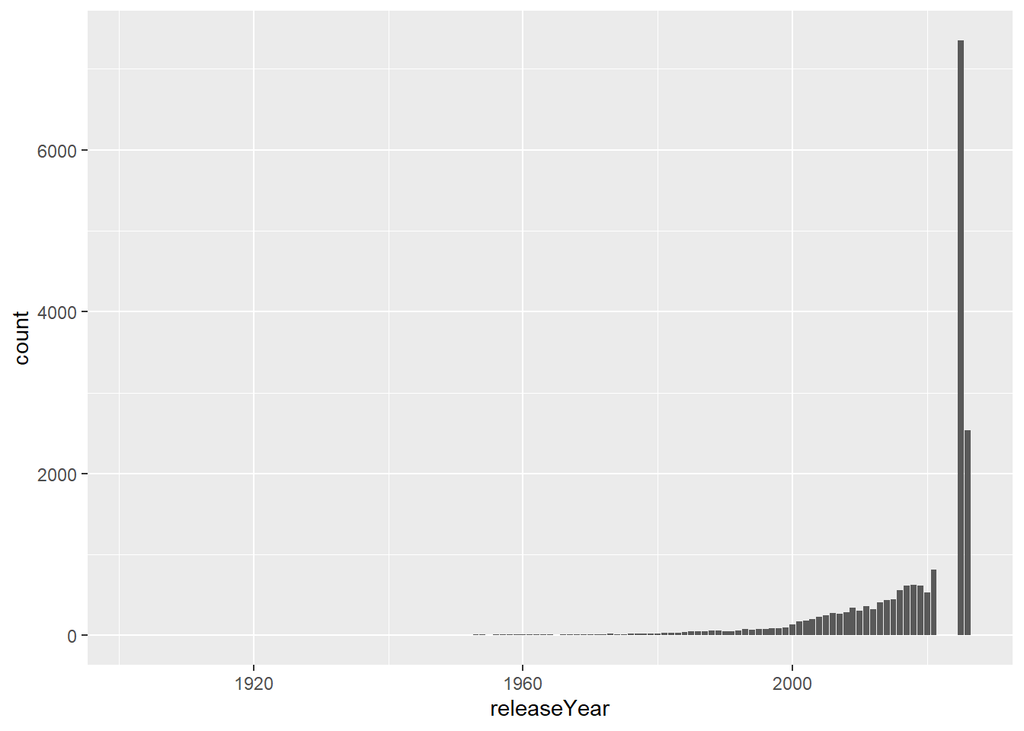

```r
ggplot(MoviesYear, aes(x = releaseYear, y = count)) +
    geom_col(na.rm = TRUE)
```

```r
MoviesYear %>%
    filter(count == max(count, na.rm = TRUE)) %>%
    select(releaseYear, count)
```

```
## # A tibble: 1 × 2
##   releaseYear count
##         <int> <int>
## 1        2025  7351
```

```r
datosF <- datos
datosF$releaseDate <- as.Date(datosF$releaseDate, format = "%Y-%m-%d")
```

```r
generes <- datosF %>%
    arrange(desc(releaseDate)) %>%
    slice(1:20) %>%
    count(genres, sort = TRUE)

generes
```

```
##                          genres n
## 1                               4
## 2                     Animation 3
## 3                         Drama 3
## 4                        Comedy 2
## 5                   Drama|Crime 2
## 6            Action|Drama|Crime 1
## 7                   Documentary 1
## 8                Romance|Comedy 1
## 9  Thriller|Mystery|Documentary 1
## 10    Thriller|Mystery|TV Movie 1
## 11                    War|Drama 1
```

```r
#barplot(generes)
```

7. ¿Las películas de qué genero principal obtuvieron mayores ganancias?
8. ¿La cantidad de actores influye en los ingresos de las películas? ¿se han hecho películas con más actores en los últimos años?
9. ¿Es posible que la cantidad de hombres y mujeres en el reparto influya en la popularidad y los ingresos de las películas?
10. ¿Quiénes son los directores que hicieron las 20 películas mejor calificadas?
11. ¿Cómo se correlacionan los presupuestos con los ingresos? ¿Los altos presupuestos significan altos ingresos? Haga los gráficos que necesite, histograma, diagrama de dispersión
12. ¿Se asocian ciertos meses de lanzamiento con mejores ingresos?
13. ¿En qué meses se han visto los lanzamientos con mejores ingresos?¿cuantas películas, en promedio, se han lanzado por mes?
14. ¿Cómo se correlacionan las calificaciones con el éxito comercial?
15. ¿La popularidad del elenco está directamente correlacionada con el éxito de taquilla?
16. ¿Qué estrategias de marketing, como videos promocionales o páginas oficiales, generan mejores resultados?